# 银行电话营销revised_by sid

<h1 align = "center">银行电话营销</h1>

## 0 实验环境

```python
!pip freeze | grep pandas;
!pip freeze | grep numpy;
!pip freeze | grep matplotlib;
!pip freeze | grep seaborn;
!pip freeze | grep scikit-learn;
!pip freeze | grep tqdm;
```

```
pandas==0.20.1
numpy==1.12.1
numpydoc==0.6.0
matplotlib==2.0.2
seaborn==0.7.1
scikit-learn==0.18.1
tqdm==4.14.0
```

```python
# 忽略警告信息
import warnings
warnings.filterwarnings('ignore')
```

## 1 数据探索

```python
% config InlineBackend.figure_format='retina'
# 载入一些基本的包
import numpy as np
import pandas as pd
import matplotlib.pyplot as plt
import seaborn as sns

# 读取介绍特征信息的文本文件
df_intro=pd.read_table("bank_introduction.txt",names=["intro"],sep="\n")

# 逐行输出方便观察
for i in range(len(df_intro)):
    print(df_intro["intro"][i])
```

```
Input variables:
# bank client data:
1 - age (numeric)
2 - job : type of job (categorical: 'admin.','blue-collar','entrepreneur','housemaid','management','retired','self-employed','services','student','technician','unemployed','unknown')
3 - marital : marital status (categorical: 'divorced','married','single','unknown'; note: 'divorced' means divorced or widowed)
4 - education (categorical: 'basic.4y','basic.6y','basic.9y','high.school','illiterate','professional.course','university.degree','unknown')
5 - default: has credit in default? (categorical: 'no','yes','unknown')
6 - housing: has housing loan? (categorical: 'no','yes','unknown')
7 - loan: has personal loan? (categorical: 'no','yes','unknown')
# related with the last contact of the current campaign:
8 - contact: contact communication type (categorical: 'cellular','telephone')
9 - month: last contact month of year (categorical: 'jan', 'feb', 'mar', ..., 'nov', 'dec')
10 - day_of_week: last contact day of the week (categorical: 'mon','tue','wed','thu','fri')
11 - duration: last contact duration, in seconds (numeric). Important note: this attribute highly affects the output target (e.g., if duration=0 then y='no'). Yet, the duration is not known before a call is performed. Also, after the end of the call y is obviously known. Thus, this input should only…
# other attributes:
12 - campaign: number of contacts performed during this campaign and for this client (numeric, includes last contact)
13 - pdays: number of days that passed by after the client was last contacted from a previous campaign (numeric; 999 means client was not previously contacted)
14 - previous: number of contacts performed before this campaign and for this client (numeric)
15 - poutcome: outcome of the previous marketing campaign (categorical: 'failure','nonexistent','success')
# social and economic context attributes
16 - emp.var.rate: employment variation rate - quarterly indicator (numeric)
17 - cons.price.idx: consumer price index - monthly indicator (numeric)
18 - cons.conf.idx: consumer confidence index - monthly indicator (numeric)
19 - euribor3m: euribor 3 month rate - daily indicator (numeric)
20 - nr.employed: number of employees - quarterly indicator (numeric)
Output variable (desired target):
21 - y - has the client subscribed a term deposit? (binary: 'yes','no')
```

客户基本信息包括年龄、职业、婚姻状态、教育程度、房贷和个人贷款等；营销活动信息包括通话⽅式、通话次数和上次营销结果等；社会经济环境信息包括就业变化率、居民消费价格指数和消费者信息指数等。

读取数据：

```python
# 为显示全部的列，添加如下的命令。
pd.set_option('display.max_columns',None)
df=pd.read_csv("bank-additional-full.csv",sep=";")
data=df.copy()
data.head()
```

|  | age | job | marital | education | default | housing | loan | contact | month | day_of_week | duration | campaign | pdays | previous | poutcome | emp.var.rate | cons.price.idx | cons.conf.idx | euribor3m | nr.employed | y |
| --- | --- | --- | --- | --- | --- | --- | --- | --- | --- | --- | --- | --- | --- | --- | --- | --- | --- | --- | --- | --- | --- |
| 0 | 56 | housemaid | married | basic.4y | no | no | no | telephone | may | mon | 261 | 1 | 999 | 0 | nonexistent | 1.1 | 93.994 | -36.4 | 4.857 | 5191.0 | no |
| 1 | 57 | services | married | high.school | unknown | no | no | telephone | may | mon | 149 | 1 | 999 | 0 | nonexistent | 1.1 | 93.994 | -36.4 | 4.857 | 5191.0 | no |
| 2 | 37 | services | married | high.school | no | yes | no | telephone | may | mon | 226 | 1 | 999 | 0 | nonexistent | 1.1 | 93.994 | -36.4 | 4.857 | 5191.0 | no |
| 3 | 40 | admin. | married | basic.6y | no | no | no | telephone | may | mon | 151 | 1 | 999 | 0 | nonexistent | 1.1 | 93.994 | -36.4 | 4.857 | 5191.0 | no |
| 4 | 56 | services | married | high.school | no | no | yes | telephone | may | mon | 307 | 1 | 999 | 0 | nonexistent | 1.1 | 93.994 | -36.4 | 4.857 | 5191.0 | no |

观察数据集的基本信息：

```python
data.info()
```

```
<class 'pandas.core.frame.DataFrame'>
RangeIndex: 41188 entries, 0 to 41187
Data columns (total 21 columns):
age               41188 non-null int64
job               41188 non-null object
marital           41188 non-null object
education         41188 non-null object
default           41188 non-null object
housing           41188 non-null object
loan              41188 non-null object
contact           41188 non-null object
month             41188 non-null object
day_of_week       41188 non-null object
duration          41188 non-null int64
campaign          41188 non-null int64
pdays             41188 non-null int64
previous          41188 non-null int64
poutcome          41188 non-null object
emp.var.rate      41188 non-null float64
cons.price.idx    41188 non-null float64
cons.conf.idx     41188 non-null float64
euribor3m         41188 non-null float64
nr.employed       41188 non-null float64
y                 41188 non-null object
dtypes: float64(5), int64(5), object(11)
memory usage: 6.6+ MB
```

```python
data.describe()
```

|  | age | duration | campaign | pdays | previous | emp.var.rate | cons.price.idx | cons.conf.idx | euribor3m | nr.employed |
| --- | --- | --- | --- | --- | --- | --- | --- | --- | --- | --- |
| count | 41188.00000 | 41188.000000 | 41188.000000 | 41188.000000 | 41188.000000 | 41188.000000 | 41188.000000 | 41188.000000 | 41188.000000 | 41188.000000 |
| mean | 40.02406 | 258.285010 | 2.567593 | 962.475454 | 0.172963 | 0.081886 | 93.575664 | -40.502600 | 3.621291 | 5167.035911 |
| std | 10.42125 | 259.279249 | 2.770014 | 186.910907 | 0.494901 | 1.570960 | 0.578840 | 4.628198 | 1.734447 | 72.251528 |
| min | 17.00000 | 0.000000 | 1.000000 | 0.000000 | 0.000000 | -3.400000 | 92.201000 | -50.800000 | 0.634000 | 4963.600000 |
| 25% | 32.00000 | 102.000000 | 1.000000 | 999.000000 | 0.000000 | -1.800000 | 93.075000 | -42.700000 | 1.344000 | 5099.100000 |
| 50% | 38.00000 | 180.000000 | 2.000000 | 999.000000 | 0.000000 | 1.100000 | 93.749000 | -41.800000 | 4.857000 | 5191.000000 |
| 75% | 47.00000 | 319.000000 | 3.000000 | 999.000000 | 0.000000 | 1.400000 | 93.994000 | -36.400000 | 4.961000 | 5228.100000 |
| max | 98.00000 | 4918.000000 | 56.000000 | 999.000000 | 7.000000 | 1.400000 | 94.767000 | -26.900000 | 5.045000 | 5228.100000 |

观察各特征的常用统计量发现，数据间存在明显的量级差异，需要做标准化处理。

## 2 数据预处理

### 缺失值处理

首先找到所有的object类型特征，并统计它们的缺失值数量。

```python
# 找到object类型特征
col=data.columns
object_list=[]
for i in range(len(col)):
    if type(data[col[i]][0])!=np.int64 and type(data[col[i]][0])!=np.float64:
        object_list.append(col[i])
```

也可以直接使用`DataFrame`的`select_dtypes`方法指定`object`对象的选择：

```python
# 找到object类型特征
object_data = data.select_dtypes(include=['object'])
object_columns = object_data.columns
object_list = object_columns.tolist()
```

```python
# 统计各特征缺失值数量
missing_list = []
for item in object_columns:
    try:
        missing_num = object_data[item].value_counts().loc['unknown']
        print "The number of missing data about %s :"  %item, missing_num
        missing_list.append(item)
    except Exception,e:
        print "The number of missing data about %s :"  %item, '0'
```

```
The number of missing data about job : 330
The number of missing data about marital : 80
The number of missing data about education : 1731
The number of missing data about default : 8597
The number of missing data about housing : 990
The number of missing data about loan : 990
The number of missing data about contact : 0
The number of missing data about month : 0
The number of missing data about day_of_week : 0
The number of missing data about poutcome : 0
The number of missing data about y : 0
```

除了`default`和`education`之外，缺失值数量都较少，直接舍弃缺失样本即可；对`default`和`education`而言，用众数填补缺失。

```python
new_data=data[data["job"]!="unknown"][data["marital"]!="unknown"][data["housing"]!="unknown"][data["loan"]!="unknown"]
new_data.head()
```

|  | age | job | marital | education | default | housing | loan | contact | month | day_of_week | duration | campaign | pdays | previous | poutcome | emp.var.rate | cons.price.idx | cons.conf.idx | euribor3m | nr.employed | y |
| --- | --- | --- | --- | --- | --- | --- | --- | --- | --- | --- | --- | --- | --- | --- | --- | --- | --- | --- | --- | --- | --- |
| 0 | 56 | housemaid | married | basic.4y | no | no | no | telephone | may | mon | 261 | 1 | 999 | 0 | nonexistent | 1.1 | 93.994 | -36.4 | 4.857 | 5191.0 | no |
| 1 | 57 | services | married | high.school | unknown | no | no | telephone | may | mon | 149 | 1 | 999 | 0 | nonexistent | 1.1 | 93.994 | -36.4 | 4.857 | 5191.0 | no |
| 2 | 37 | services | married | high.school | no | yes | no | telephone | may | mon | 226 | 1 | 999 | 0 | nonexistent | 1.1 | 93.994 | -36.4 | 4.857 | 5191.0 | no |
| 3 | 40 | admin. | married | basic.6y | no | no | no | telephone | may | mon | 151 | 1 | 999 | 0 | nonexistent | 1.1 | 93.994 | -36.4 | 4.857 | 5191.0 | no |
| 4 | 56 | services | married | high.school | no | no | yes | telephone | may | mon | 307 | 1 | 999 | 0 | nonexistent | 1.1 | 93.994 | -36.4 | 4.857 | 5191.0 | no |

```python
# 舍弃一部分缺失样本
new_data=data[data["job"]!="unknown"][data["marital"]!="unknown"][data["housing"]!="unknown"][data["loan"]!="unknown"]
new_data.index=range(len(new_data))

# 用众数填补数量多的缺失值
new_data["default"].replace('unknown', new_data["default"].value_counts().index[0], inplace=True)
new_data['education'].replace('unknown', new_data["education"].value_counts().index[0], inplace=True)
```

```python
# 检查填补后的情况
print " This is the new distribution of default:"
print new_data["default"].value_counts()
print " This is the new distribution of education:"
print new_data["education"].value_counts()
```

```
 This is the new distribution of default:
no     39800
yes        3
Name: default, dtype: int64
 This is the new distribution of education:
university.degree      13379
high.school             9244
basic.9y                5856
professional.course     5100
basic.4y                4002
basic.6y                2204
illiterate                18
Name: education, dtype: int64
```

### 数值化转换

```python
# 把object类型特征用one-hot变量来表示
object_list.remove("y")
for item in object_list:
    dummies=pd.get_dummies(new_data[item],prefix=item)
    new_data=pd.concat([new_data,dummies],axis=1)
    del new_data[item]

# 目标特征数值化
new_data["label"]=0
new_data["label"][new_data["y"]=="yes"]=1
new_data["label"][new_data["y"]=="no"]=0
del new_data["y"]
```

### 可视化

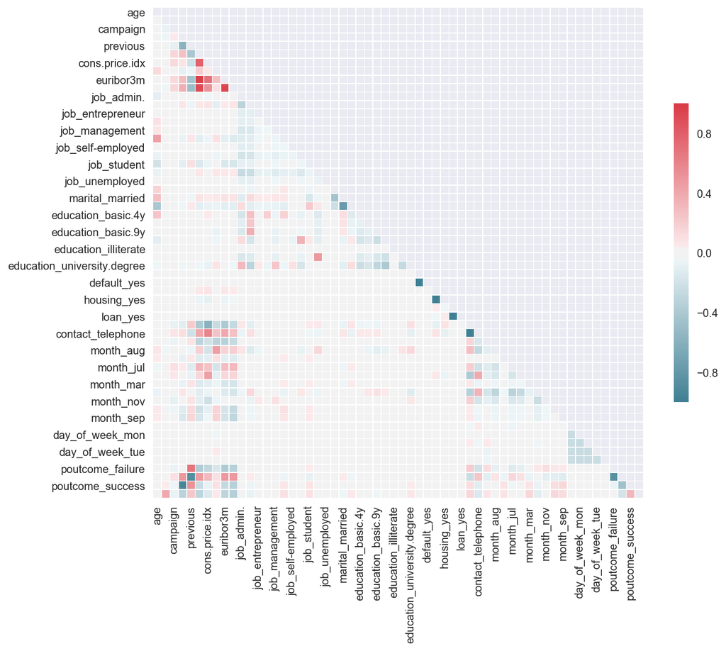

```python
# 计算相关矩阵
corr = new_data.corr()

# 设置图形类型为下三角矩阵
mask = np.zeros_like(corr, dtype=np.bool)
mask[np.triu_indices_from(mask)] = True

# 做相关矩阵图
f, ax = plt.subplots(figsize=(10, 10))
cmap = sns.diverging_palette(220, 10, as_cmap=True)
sns.heatmap(corr, mask=mask, cmap=cmap, vmax=1.0,
            square=True, xticklabels=2, yticklabels=2,
            linewidths=.3, cbar_kws={"shrink": .5}, ax=ax)
plt.show()
```

```python
new_data.columns
```

```
Index([u'age', u'duration', u'campaign', u'pdays', u'previous',
       u'emp.var.rate', u'cons.price.idx', u'cons.conf.idx', u'euribor3m',
       u'nr.employed', u'job_admin.', u'job_blue-collar', u'job_entrepreneur',
       u'job_housemaid', u'job_management', u'job_retired',
       u'job_self-employed', u'job_services', u'job_student',
       u'job_technician', u'job_unemployed', u'marital_divorced',
       u'marital_married', u'marital_single', u'education_basic.4y',
       u'education_basic.6y', u'education_basic.9y', u'education_high.school',
       u'education_illiterate', u'education_professional.course',
       u'education_university.degree', u'default_no', u'default_yes',
       u'housing_no', u'housing_yes', u'loan_no', u'loan_yes',
       u'contact_cellular', u'contact_telephone', u'month_apr', u'month_aug',
       u'month_dec', u'month_jul', u'month_jun', u'month_mar', u'month_may',
       u'month_nov', u'month_oct', u'month_sep', u'day_of_week_fri',
       u'day_of_week_mon', u'day_of_week_thu', u'day_of_week_tue',
       u'day_of_week_wed', u'poutcome_failure', u'poutcome_nonexistent',
       u'poutcome_success', u'label'],
      dtype='object')
```

纵坐标的最下面一行是目标特征，可见还是有很多特征与之相关的，颜色最深的是特征`duration`，进一步观察它们之间的关系：

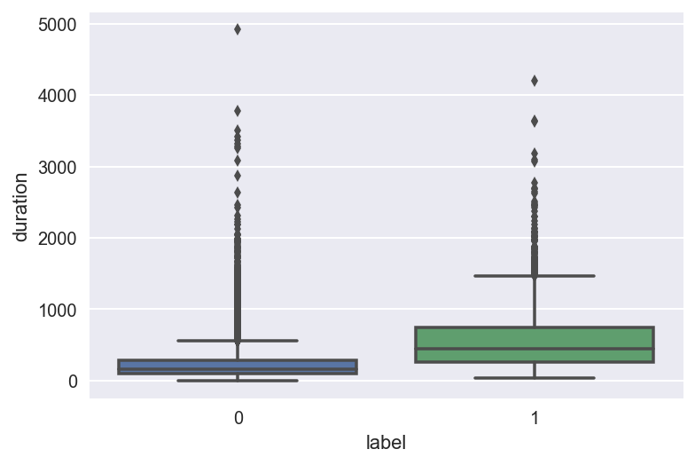

```python
f, ax1 = plt.subplots(1, 1, figsize=(6,4))
sns.boxplot(x="label",y='duration',data=new_data,ax=ax1)
plt.show()
```

容易发现，特征`duration`对目标特征影响很大，但是注意到特征信息：

duration: last contact duration, in seconds (numeric). Important note: this attribute highly affects the output target (e.g., if duration=0 then y='no'). Yet, the duration is not known before a call is performed. Also, after the end of the call y is obviously known. Thus, this input should only be included for benchmark purposes and should be discarded if the intention is to have a realistic predictive model.

这说明特征`duration`不是能随时获得的，所以在建立模型时，我们要舍弃该特征。

### 0-1标准化

```python
from sklearn import  preprocessing as prep
x=new_data.copy()
del x["label"]
del x["duration"]
y=new_data["label"]
minmax_scale=prep.MinMaxScaler().fit( x[ x.columns])
x[ x.columns]=minmax_scale.transform( x[ x.columns])
x.head()
```

|  | age | campaign | pdays | previous | emp.var.rate | cons.price.idx | cons.conf.idx | euribor3m | nr.employed | job_admin. | job_blue-collar | job_entrepreneur | job_housemaid | job_management | job_retired | job_self-employed | job_services | job_student | job_technician | job_unemployed | marital_divorced | marital_married | marital_single | education_basic.4y | education_basic.6y | education_basic.9y | education_high.school | education_illiterate | education_professional.course | … |
| --- | --- | --- | --- | --- | --- | --- | --- | --- | --- | --- | --- | --- | --- | --- | --- | --- | --- | --- | --- | --- | --- | --- | --- | --- | --- | --- | --- | --- | --- | --- |
| 0 | 0.481481 | 0.0 | 1.0 | 0.0 | 0.9375 | 0.698753 | 0.60251 | 0.957379 | 0.859735 | 0.0 | 0.0 | 0.0 | 1.0 | 0.0 | 0.0 | 0.0 | 0.0 | 0.0 | 0.0 | 0.0 | 0.0 | 1.0 | 0.0 | 1.0 | 0.0 | 0.0 | 0.0 | 0.0 | 0.0 | … |
| 1 | 0.493827 | 0.0 | 1.0 | 0.0 | 0.9375 | 0.698753 | 0.60251 | 0.957379 | 0.859735 | 0.0 | 0.0 | 0.0 | 0.0 | 0.0 | 0.0 | 0.0 | 1.0 | 0.0 | 0.0 | 0.0 | 0.0 | 1.0 | 0.0 | 0.0 | 0.0 | 0.0 | 1.0 | 0.0 | 0.0 | … |
| 2 | 0.246914 | 0.0 | 1.0 | 0.0 | 0.9375 | 0.698753 | 0.60251 | 0.957379 | 0.859735 | 0.0 | 0.0 | 0.0 | 0.0 | 0.0 | 0.0 | 0.0 | 1.0 | 0.0 | 0.0 | 0.0 | 0.0 | 1.0 | 0.0 | 0.0 | 0.0 | 0.0 | 1.0 | 0.0 | 0.0 | … |
| 3 | 0.283951 | 0.0 | 1.0 | 0.0 | 0.9375 | 0.698753 | 0.60251 | 0.957379 | 0.859735 | 1.0 | 0.0 | 0.0 | 0.0 | 0.0 | 0.0 | 0.0 | 0.0 | 0.0 | 0.0 | 0.0 | 0.0 | 1.0 | 0.0 | 0.0 | 1.0 | 0.0 | 0.0 | 0.0 | 0.0 | … |
| 4 | 0.481481 | 0.0 | 1.0 | 0.0 | 0.9375 | 0.698753 | 0.60251 | 0.957379 | 0.859735 | 0.0 | 0.0 | 0.0 | 0.0 | 0.0 | 0.0 | 0.0 | 1.0 | 0.0 | 0.0 | 0.0 | 0.0 | 1.0 | 0.0 | 0.0 | 0.0 | 0.0 | 1.0 | 0.0 | 0.0 | … |

## 3 特征选择及模型建立

本案例的要求是找到影响订购产品的关键特征并建立模型预测，所以选择封装式和嵌入式的特征选择方法比较合适，在这里我们尝试了两种嵌入式方法：正则化模型和基于树的模型。数据预处理后`x`共有56个特征，为了能有效减少特征数量我们采用`L1`正则化，因为在本案例中模型效果比稳定性更重要；基于树的模型采用`ExtraTrees`模型，该模型是一个类似于随机森林的集成模型，选择集成模型也是为了提升模型预测效果，选择分支节点的标准分别尝试了`Gini`不纯度和`Entropy`熵。

首先以7:3比例随机地划分训练集和测试集：

```python
# 随机地划分训练集和测试集
from sklearn.cross_validation import train_test_split
train_x, test_x, train_y, test_y = train_test_split(x, y, test_size=0.3, random_state=0)
```

首先定义三个之后需要用到的函数：

- 函数`evaluate(pred,test_y)`用来对分类结果进行评价；
- 函数`find_name(new_feature, df_feature)`用来输出关键特征的名称；
- 函数`FS_importance(arr_importance, col, N)`用来根据特征重要性选择特征。

```python
from sklearn import metrics
from sklearn.metrics import classification_report

"""
函数evaluate(pred,test_y)用来对分类结果进行评价；
输入：真实的分类、预测的分类结果
输出：分类的准确率、混淆矩阵等
"""
def evaluate(pred,test_y):

    # 输出分类的准确率
    print("Accuracy: %.4f"  % (metrics.accuracy_score(test_y,pred)))

    # 输出衡量分类效果的各项指标
    print(classification_report(test_y, pred))

    # 更直观的，我们通过seaborn画出混淆矩阵
    %matplotlib inline
    plt.figure(figsize=(6,4))
    colorMetrics = metrics.confusion_matrix(test_y,pred)

    # 坐标y代表test_y，即真实的类别，坐标x代表估计出的类别pred
    sns.heatmap(colorMetrics,annot=True,fmt='d',xticklabels=[0,1],yticklabels=[0,1])
    sns.plt.show()

"""
函数find_name(new_feature, df_feature)用来输出关键特征的名称；
输入：原始特征、选择的关键特征；
输出：关键特征的名称
"""
def find_name(new_feature, df_feature):

    # 定义列表存储关键特征名称
    feature_name=[]
    col=df_feature.columns

    # 寻找关键特征的名称信息
    for i in range(int(new_feature.shape[0])):
        for j in range(df_feature.shape[1]):

            # 判别标准为new_feature中的特征向量与df_feature中的特征向量一致
            if np.mean(abs(new_feature[i]-df_feature[col[j]]))==0:
                feature_name.append(col[j])
                print i+1,col[j]
                break
    return feature_name

"""
函数FS_importance(arr_importance, col, N)用来根据特征重要性选择特征
输入：特征重要性、特征名称集、选择的特征个数
输出：根据特征重要性求出来的前N个特征
"""
def FS_importance(arr_importance, col, N):

    # 字典存储
    dict_order=dict(zip(col, arr_importance))

    # 按特征重要性大小排序
    new_feature=sorted(dict_order.iteritems(),key=lambda item:item[1], reverse=True)
    feature_top, score=zip(*new_feature)
    return list(feature_top[:N])
```

### 3.1 正则化模型

本节包括三个部分：  
1）特征选择：特征选择采用`L1`正则化，分别尝试了惩罚系数`C`取不同值时的模型效果，模型效果是用在训练集上5折交叉验证得到的平均准确率来衡量的，通过做图对比，找到使模型效果最好的惩罚系数；  
2）在特征子集上建立模型：利用在特征选择中得到的最优子集建立模型；  
3）在特征全集上建立模型：利用原始的特征全集建立模型，并与第2部分的模型效果作对比，观察特征选择对模型效果的影响。

### 特征选择

探讨选择不同惩罚系数对特征选择效果的影响，并在训练集上进行5折交叉验证以验证模型效果，`baseline`是用特征全集在训练集上进行5折交叉验证得到的模型平均准确率。

```python
# 导入交叉验证和特征选择需要的模块
import tqdm
from sklearn import cross_validation
from sklearn.svm import LinearSVC
from sklearn.feature_selection import SelectFromModel

# 定义不进行正则化的模型
lsvc = LinearSVC(C=1e-5)

# 交叉验证计算应用特征全集的平均准确率
score=cross_validation.cross_val_score(lsvc, train_x, train_y, cv=5)

# 探讨不同参数对特征选择效果的影响
# xx代表参数集合
acc_subset=[]
xx=np.array(range(5,205,5))*0.01
for i in tqdm.tqdm(xx):

    # 定义进行L1正则化特征选择的模型
    lsvc_l1 = LinearSVC(C=i, penalty="l1", dual=False)

    # 交叉验证计算应用特征子集的平均准确率
    scores=cross_validation.cross_val_score(lsvc_l1, train_x, train_y, cv=5)
    acc_subset.append(scores.mean())
```

画图来观察不同惩罚系数对特征选择效果的影响：

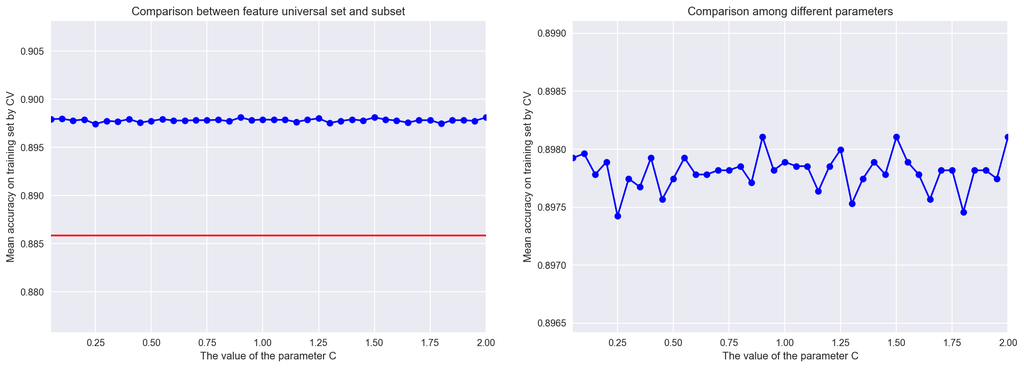

```python
# yy代表不同参数下应用特征子集的平均准确率
# y0代表应用特征全集的平均准确率，以此作baseline
yy=acc_subset
y0=[score.mean()]*len(xx)

# 比较应用特征全集和特征子集的区别
fig=plt.figure(figsize=(18,6))
ax1=fig.add_subplot(1,2,1)
plt.plot(xx,yy,"bo-")
plt.plot(xx,y0,"r-")
ax1.set_xlabel("The value of the parameter C")
ax1.set_ylabel("Mean accuracy on training set by CV")
ax1.set_title("Comparison between feature universal set and subset")
ax1.set_ylim([score.mean()-0.01,max(yy)+0.01])
ax1.set_xlim([min(xx),max(xx)])

# 观察不同特征子集的区别
ax2=fig.add_subplot(1,2,2)
plt.plot(xx,yy,"bo-")
plt.plot(xx,y0,"r-")
ax2.set_xlabel("The value of the parameter C")
ax2.set_ylabel("Mean accuracy on training set by CV")
ax2.set_title("Comparison among different parameters")
ax2.set_ylim([min(yy)-0.001,max(yy)+0.001])
ax2.set_xlim([min(xx),max(xx)])
plt.show()
```

### 在特征子集上建立模型

在上一部分得到的最优子集上建立`LinearSVC`模型，并输出经`L1`正则化选出来的特征名称。

```python
# 建立L1正则化模型
lsvc_l1 = LinearSVC(C=1.7, penalty="l1", dual=False).fit(train_x, train_y)
pred=lsvc_l1.predict(test_x)

# 输出经L1正则化选出的特征名称
model = SelectFromModel(lsvc_l1,prefit=True)
new_train_x = model.transform(train_x).T
FS_result=find_name(new_train_x, train_x)
```

```
1 age
2 campaign
3 pdays
4 emp.var.rate
5 cons.price.idx
6 cons.conf.idx
7 euribor3m
8 nr.employed
9 job_admin.
10 job_blue-collar
11 job_housemaid
12 job_management
13 job_retired
14 job_self-employed
15 job_services
```

[output cut: 33 more lines]

将模型各项评价指标值存在列表`evaluate_subset`中：

```python
from sklearn import metrics
#accuracy
acc_subset = metrics.accuracy_score(test_y,pred)

#precision
precision_subset = metrics.precision_score(test_y,pred,average='weighted')

#recall
recall_subset = metrics.recall_score(test_y,pred,average='weighted')

#f1-score
f1_subset = metrics.f1_score(test_y,pred,average='weighted')
evaluate_subset = [acc_subset,precision_subset,recall_subset,f1_subset]
```

详细的模型效果评价如下图混淆矩阵所示：

```
Accuracy: 0.9044
             precision    recall  f1-score   support

          0       0.91      0.99      0.95     10635
          1       0.71      0.21      0.33      1306

avg / total       0.89      0.90      0.88     11941
```

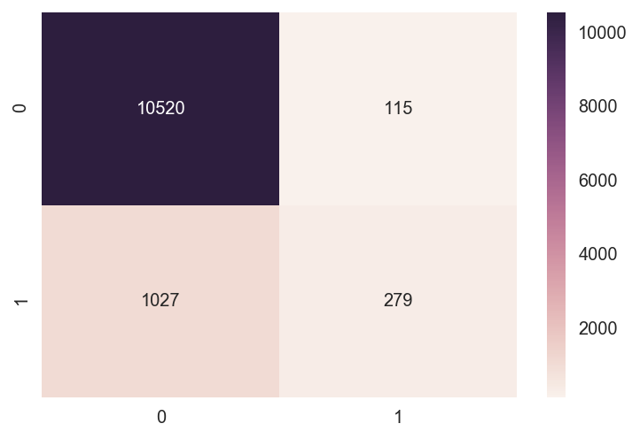

```python
evaluate(pred,test_y)
```

### 对比：在特征全集上建立模型

在特征全集上建立同样的`LinearSVC`模型：

```python
# 建立不进行正则化的模型(设置C为一个接近0的数)
lsvc = LinearSVC(C=1e-5)
lsvc_model = lsvc.fit(train_x,train_y)
pred=lsvc_model.predict(test_x)
```

更详细的模型效果评价：

```python
#accuracy
acc_all = metrics.accuracy_score(test_y,pred)

#precision
precision_all = metrics.precision_score(test_y,pred,average='weighted')

#recall
recall_all = metrics.recall_score(test_y,pred,average='weighted')

#f1-score
f1_all = metrics.f1_score(test_y,pred,average='weighted')
evaluate_all = [acc_all,precision_all,recall_all,f1_all]
```

```
Accuracy: 0.8906
             precision    recall  f1-score   support

          0       0.89      1.00      0.94     10635
          1       0.00      0.00      0.00      1306

avg / total       0.79      0.89      0.84     11941
```

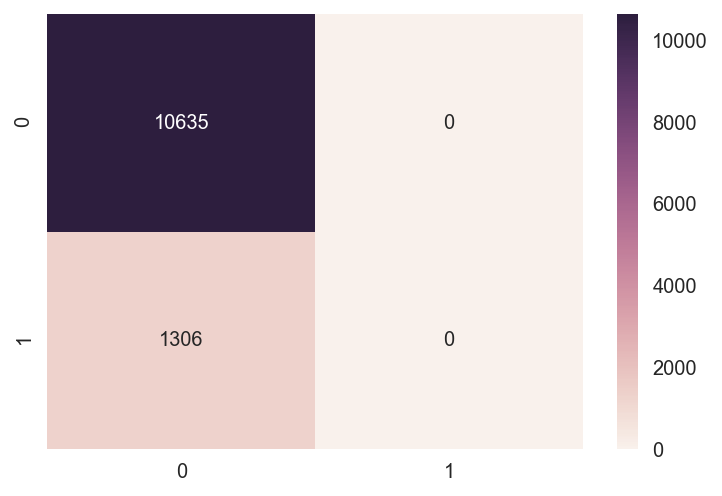

```python
evaluate(pred,test_y)
```

更直观地对比特征子集和特征全集带来的模型效果差异：

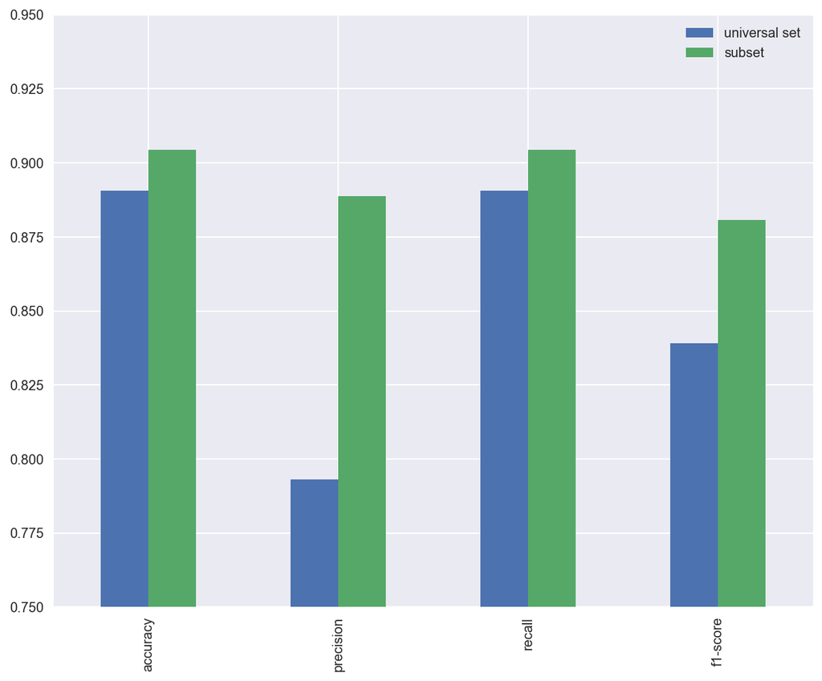

```python
index=["accuracy","precision","recall","f1-score"]
data = zip(evaluate_all,evaluate_subset)
df=pd.DataFrame(data,columns=["universal set","subset"],index=index)
df.plot(kind="bar",figsize=(10,8))
plt.ylim([0.75,0.95])
plt.show()
```

应用特征子集建立的模型在各方面都有了更好的性能，说明在建模前进行特征选择是很有必要的。特别是使用数据全集得到的模型，将所有测试集的样本预测负类(`label`值为`0`)，这个模型其实是没有任何意义的。

### 3.2 基于树的模型

本节包括三个部分：  
1）特征选择：特征选择分别尝试了以`Gini`不纯度和`Entropy`为指标，并对比了选择不同数量特征对模型效果的影响，模型效果是用在训练集上5折交叉验证得到的平均准确率来衡量的，通过做图对比，找到使模型效果最好的特征个数；  
2）在特征子集上建立模型：利用在特征选择中得到的最优子集建立模型；  
3）在特征全集上建立模型：利用原始的特征全集建立模型，并与第2部分的模型效果作对比，观察特征选择对模型效果的影响。

### 特征选择

分别以`Gini`不纯度和`Entropy`为特征选择指标，并探讨选择不同特征个数对特征选择效果的影响，在训练集上进行5折交叉验证以验证模型效果，`baseline`是用特征全集在训练集上进行5折交叉验证得到的模型平均准确率。

```python
# 定义以Gini不纯度为分类指标的模型
from sklearn.ensemble import ExtraTreesClassifier
clf_gini = ExtraTreesClassifier(criterion='gini')

# 在训练集上拟合模型，获得特征重要性得分
clf_gini = clf_gini.fit(train_x, train_y)
importance_gini=clf_gini.feature_importances_

# 交叉验证计算应用特征全集的平均准确率
score_gini=cross_validation.cross_val_score(clf_gini, train_x, train_y, cv=5)

# 定义以Entropy熵为分类指标的模型
from sklearn.ensemble import ExtraTreesClassifier
clf_entropy = ExtraTreesClassifier(criterion='entropy')

# 在训练集上拟合模型，获得特征重要性得分
clf_entropy = clf_entropy.fit(train_x, train_y)
importance_entropy=clf_entropy.feature_importances_

# 交叉验证计算应用特征全集的平均准确率
score_entropy=cross_validation.cross_val_score(clf_entropy, train_x, train_y, cv=5)
```

```python
# 以Gini不纯度为指标
# 探讨不同特征个数对特征选择效果的影响
# xx代表特征个数集合
acc_subset_gini=[]
xx=np.array(range(1,56,1))
for i in tqdm.tqdm(xx):

    # 定义ExtraTrees模型
    clf_gini = ExtraTreesClassifier(criterion='gini')

    # 根据特征重要性选择特征
    feature=FS_importance(importance_gini, train_x.columns, i)
    new_train_x=train_x[feature]

    # 交叉验证计算应用特征子集的平均准确率
    scores=cross_validation.cross_val_score(clf_gini, new_train_x, train_y, cv=5)
    acc_subset_gini.append(scores.mean())
```

```python
# 以Entropy熵为指标
# 探讨不同特征个数对特征选择效果的影响
# xx代表特征个数集合
acc_subset_entropy=[]
xx=np.array(range(1,56,1))
for i in tqdm.tqdm(xx):

    # 定义ExtraTrees模型
    clf_entropy = ExtraTreesClassifier(criterion='entropy')

    # 根据特征重要性选择特征
    feature=FS_importance(importance_entropy, train_x.columns, i)
    new_train_x=train_x[feature]

    # 交叉验证计算应用特征子集的平均准确率
    scores=cross_validation.cross_val_score(clf_entropy, new_train_x, train_y, cv=5)
    acc_subset_entropy.append(scores.mean())
```

画图来观察不同特征个数对特征选择效果的影响：

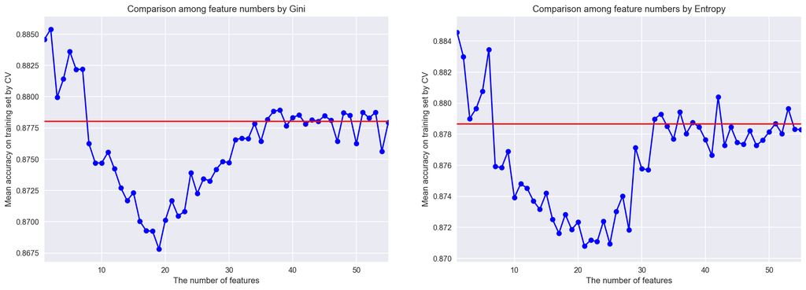

```python
# 以Gini不纯度为指标
# yy代表不同特征个数下应用特征子集的平均准确率
# y0代表应用特征全集的平均准确率，以此作baseline
yy=acc_subset_gini
y0=[score_gini.mean()]*len(xx)

# 比较应用特征全集和特征子集的区别
fig=plt.figure(figsize=(18,6))
ax1=fig.add_subplot(1,2,1)
plt.plot(xx,yy,"bo-")
plt.plot(xx,y0,"r-")
ax1.set_xlabel("The number of features")
ax1.set_ylabel("Mean accuracy on training set by CV")
ax1.set_title("Comparison among feature numbers by Gini")
ax1.set_ylim([min(yy)-0.001,max(yy)+0.001])
ax1.set_xlim([min(xx),max(xx)])

# yy代表不同参数下应用特征子集的平均准确率
# y0代表应用特征全集的平均准确率，以此作baseline
yy=acc_subset_entropy
y0=[score_entropy.mean()]*len(xx)

# 观察不同特征子集的区别
ax2=fig.add_subplot(1,2,2)
plt.plot(xx,yy,"bo-")
plt.plot(xx,y0,"r-")
ax2.set_xlabel("The number of features")
ax2.set_ylabel("Mean accuracy on training set by CV")
ax2.set_title("Comparison among feature numbers by Entropy")
ax2.set_ylim([min(yy)-0.001,max(yy)+0.001])
ax2.set_xlim([min(xx),max(xx)])
plt.show()
```

上述两图的横坐标都是特征个数，纵坐标都是交叉验证得到的平均准确率，蓝色折现代表不同特征个数下应用特征子集的模型准确率，红色直线则是我们的`baseline`，即应用特征全集在同样模型上得到的准确率，不同的是左图是以`Gini`不纯度为指标做特征选择的，而右图是以`Entropy`为指标做特征选择。可以发现，特征个数对特征选择的效果影响很大，在一些特征子集上（比如特征个数为2、5、6、55时），模型可以取得比`baseline`更好的效果；但在另一些特征子集上（比如特征个数为14、15、16时），模型效果反而降低了很多。从图上发现，特征子集中包含2个特征时，模型效果最好，但是经过试验发现特征个数太少时虽然准确率确实高，却会造成很低的`F1`值，最终我们选择以`Entropy`为指标得到的特征个数为6的特征子集为最优子集候选。这里提醒大家，对于分类问题，不能只看准确率，其他的指标也很重要，对特征子集的选择要从多方面综合考虑。

前6个关键特征如下：

```python
print "The most important 6 features computed by mini:"
print(FS_importance(importance_gini, train_x.columns, 6))
print "The most important 6 features computed by entropy:"
print(FS_importance(importance_entropy, train_x.columns, 6))
```

```
The most important 6 features computed by mini:
['age', 'campaign', 'euribor3m', 'pdays', 'nr.employed', 'emp.var.rate']
The most important 6 features computed by entropy:
['age', 'euribor3m', 'campaign', 'emp.var.rate', 'nr.employed', 'pdays']
```

### 在特征子集上建立模型

在上一部分得到的最优子集上建立`ExtraTrees`模型，并输出以`entropy`为指标选出来的特征名称。

```python
# 定义ExtraTrees模型
clf_entropy = ExtraTreesClassifier(criterion='entropy')

# 根据特征重要性选择特征
feature=FS_importance(importance_entropy, train_x.columns, 6)
new_train_x=train_x[feature]
new_test_x=test_x[feature]

clf_entropy = clf_entropy.fit(new_train_x, train_y)
pred=clf_entropy.predict(new_test_x)
```

详细的模型效果评价：

```python
#accuracy
acc_subset = metrics.accuracy_score(test_y,pred)

#precision
precision_subset = metrics.precision_score(test_y,pred,average='weighted')

#recall
recall_subset = metrics.recall_score(test_y,pred,average='weighted')

#f1-score
f1_subset = metrics.f1_score(test_y,pred,average='weighted')
evaluate_subset = [acc_subset,precision_subset,recall_subset,f1_subset]
```

```
Accuracy: 0.8869
             precision    recall  f1-score   support

          0       0.92      0.96      0.94     10635
          1       0.47      0.28      0.36      1306

avg / total       0.87      0.89      0.87     11941
```

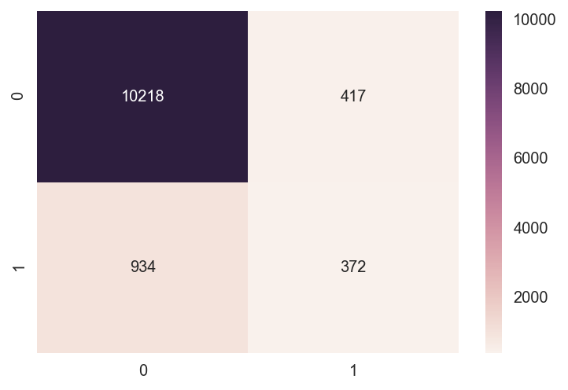

```python
evaluate(pred,test_y)
```

### 对比：在特征全集上建立模型

在特征全集上建立同样的`ExtraTrees`模型：

```python
from sklearn.ensemble import ExtraTreesClassifier
clf_entropy = ExtraTreesClassifier(criterion='entropy')
clf_entropy = clf_entropy.fit(train_x, train_y)
pred=clf_entropy.predict(test_x)
```

详细的模型效果评价：

```python
#accuracy
acc_all = metrics.accuracy_score(test_y,pred)

#precision
precision_all = metrics.precision_score(test_y,pred,average='weighted')

#recall
recall_all = metrics.recall_score(test_y,pred,average='weighted')

#f1-score
f1_all = metrics.f1_score(test_y,pred,average='weighted')
evaluate_all = [acc_all,precision_all,recall_all,f1_all]
```

```
Accuracy: 0.8785
             precision    recall  f1-score   support

          0       0.92      0.95      0.93     10635
          1       0.42      0.30      0.35      1306

avg / total       0.86      0.88      0.87     11941
```

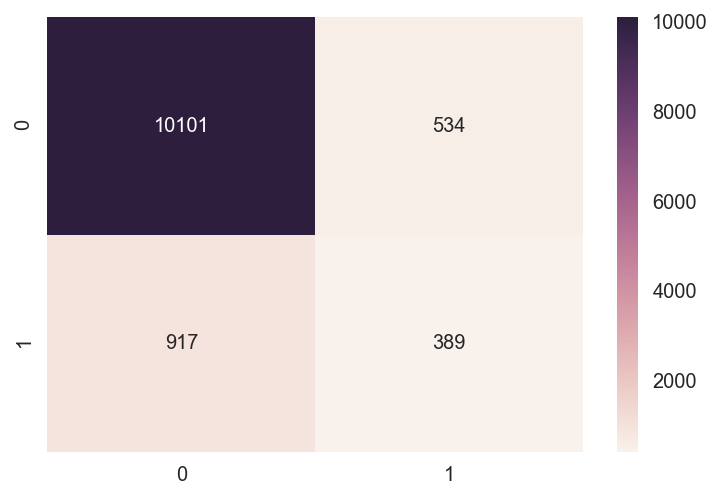

```python
evaluate(pred,test_y)
```

更直观地对比特征子集和特征全集带来的模型效果差异：

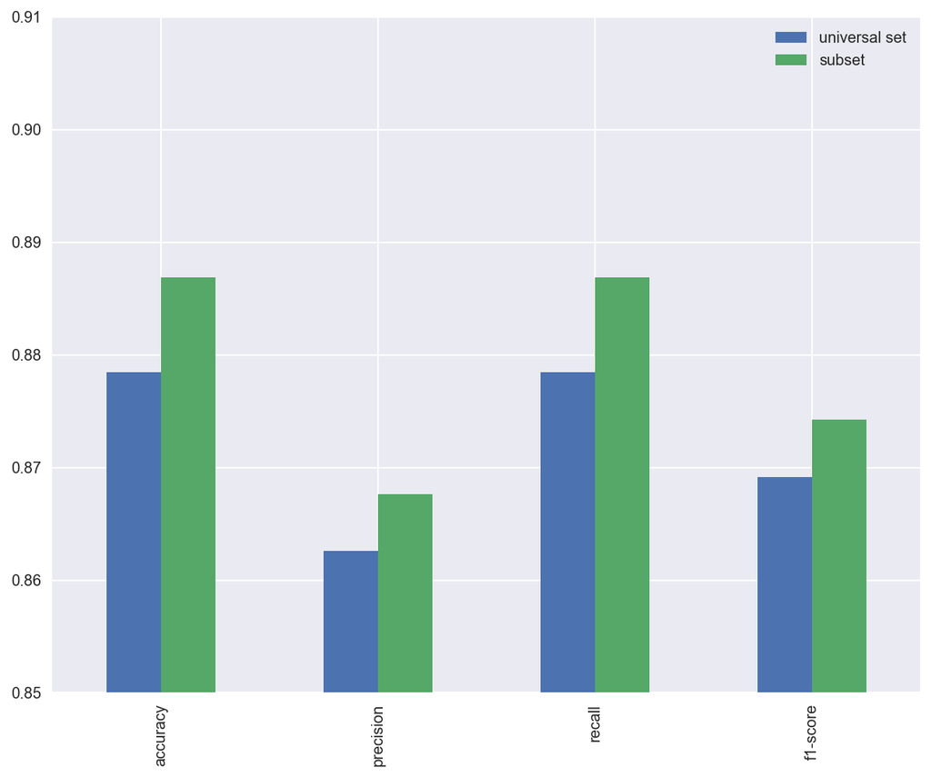

```python
index=["accuracy","precision","recall","f1-score"]
data = zip(evaluate_all,evaluate_subset)
df=pd.DataFrame(data,columns=["universal set","subset"],index=index)
df.plot(kind="bar",figsize=(10,8))
plt.ylim([0.85,0.91])
plt.show()
```

应用特征子集建立的模型在各方面都有了更好的性能，说明在建模前进行特征选择是很有必要的。

## 4 特征理解与评估

我们共尝试了三种特征选择方法：`L1`正则化、`Gini`不纯度、`Entropy`，这三种方法都认为特征`age`和`campaign`对是否订购产品影响最大，所以我们想进一步观察一下这种影响关系是怎样的。

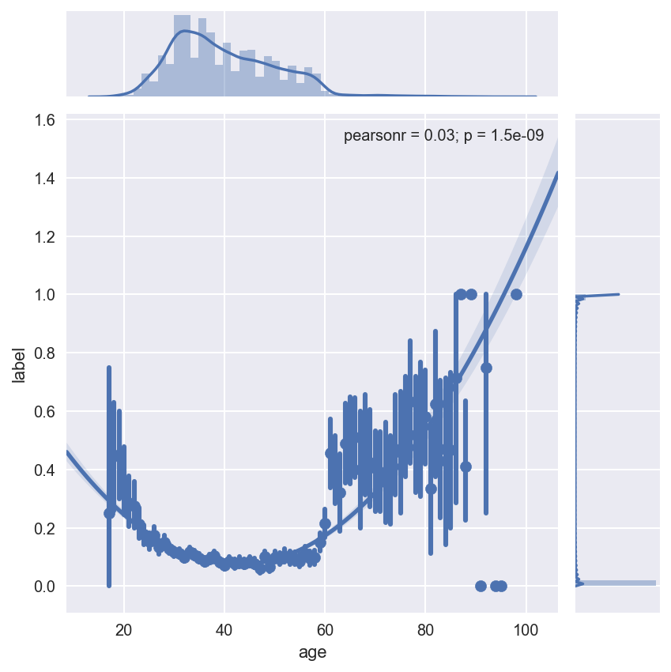

```python
# 进一步观察age和label的关系
sns.jointplot(x='age',y='label',data=new_data,kind='reg',x_estimator= np.mean,order=2)
plt.show()
```

因为`label`是离散变量，所以用其均值代替，可以发现`age`与`label`之间存在一种二次关系，中年人不太喜欢订购产品，反而是年轻人和老年人订购产品的比率更高。该发现可以引导银行对电话营销的目标人群做更精准的定位。

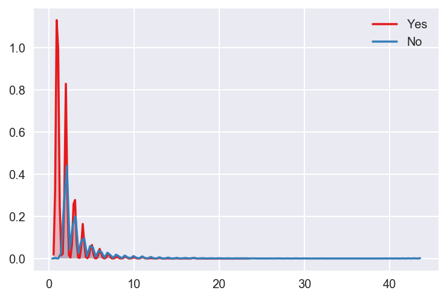

```python
# 进一步观察campaign和label的关系
f, ax1 = plt.subplots(1, 1, sharex=True, figsize=(6, 4))
c1, c2 = sns.color_palette('Set1', 2)
sns.kdeplot(new_data['campaign'][new_data["label"]==1], shade=True, color=c1, label='Yes',ax=ax1)
sns.kdeplot(new_data['campaign'][new_data["label"]==0], shade=True, color=c2, label='No', ax=ax1)
plt.show()
```

特征`campaign`代表和客户的联系次数，红色分布代表订购产品的`campaign`数据分布，蓝色分布代表不订购的`campaign`数据分布，可以发现：红色分布更偏向于0，数值分布更小，这说明当联系次数少时，客户更倾向于订购产品，对银行而言，应控制业务员频繁联系客户的行为。

## 5 数据降维

在本小节，我们首先对包含56个特征的数据集`train_x`进行降维，使用不同方法进行数据降维并在二维平面上进行可视化分析，最后分析数据降维对模型预测效果的影响。

我们先列出之后会使用到的并且在前面已经定义过的变量：

| 数据集名 | 含义 |
| --- | --- |
| `train_x` | 包含56个特征的训练数据集 |
| `test_x` | 包含56个特征的测试数据集 |
| `train_y` | 训练集真实标签 |
| `test_y` | 测试集真实标签 |

```python
# 使用索引降序的方式排列DataFrame
train_x.sort_index(inplace=True)
train_y.sort_index(inplace=True)
new_train_x.sort_index(inplace=True)
train_x.head()
```

|  | age | campaign | pdays | previous | emp.var.rate | cons.price.idx | cons.conf.idx | euribor3m | nr.employed | job_admin. | job_blue-collar | job_entrepreneur | job_housemaid | job_management | job_retired | job_self-employed | job_services | job_student | job_technician | job_unemployed | marital_divorced | marital_married | marital_single | education_basic.4y | education_basic.6y | education_basic.9y | education_high.school | education_illiterate | education_professional.course | … |
| --- | --- | --- | --- | --- | --- | --- | --- | --- | --- | --- | --- | --- | --- | --- | --- | --- | --- | --- | --- | --- | --- | --- | --- | --- | --- | --- | --- | --- | --- | --- |
| 0 | 0.481481 | 0.0 | 1.0 | 0.0 | 0.9375 | 0.698753 | 0.60251 | 0.957379 | 0.859735 | 0.0 | 0.0 | 0.0 | 1.0 | 0.0 | 0.0 | 0.0 | 0.0 | 0.0 | 0.0 | 0.0 | 0.0 | 1.0 | 0.0 | 1.0 | 0.0 | 0.0 | 0.0 | 0.0 | 0.0 | … |
| 1 | 0.493827 | 0.0 | 1.0 | 0.0 | 0.9375 | 0.698753 | 0.60251 | 0.957379 | 0.859735 | 0.0 | 0.0 | 0.0 | 0.0 | 0.0 | 0.0 | 0.0 | 1.0 | 0.0 | 0.0 | 0.0 | 0.0 | 1.0 | 0.0 | 0.0 | 0.0 | 0.0 | 1.0 | 0.0 | 0.0 | … |
| 2 | 0.246914 | 0.0 | 1.0 | 0.0 | 0.9375 | 0.698753 | 0.60251 | 0.957379 | 0.859735 | 0.0 | 0.0 | 0.0 | 0.0 | 0.0 | 0.0 | 0.0 | 1.0 | 0.0 | 0.0 | 0.0 | 0.0 | 1.0 | 0.0 | 0.0 | 0.0 | 0.0 | 1.0 | 0.0 | 0.0 | … |
| 3 | 0.283951 | 0.0 | 1.0 | 0.0 | 0.9375 | 0.698753 | 0.60251 | 0.957379 | 0.859735 | 1.0 | 0.0 | 0.0 | 0.0 | 0.0 | 0.0 | 0.0 | 0.0 | 0.0 | 0.0 | 0.0 | 0.0 | 1.0 | 0.0 | 0.0 | 1.0 | 0.0 | 0.0 | 0.0 | 0.0 | … |
| 5 | 0.345679 | 0.0 | 1.0 | 0.0 | 0.9375 | 0.698753 | 0.60251 | 0.957379 | 0.859735 | 0.0 | 0.0 | 0.0 | 0.0 | 0.0 | 0.0 | 0.0 | 1.0 | 0.0 | 0.0 | 0.0 | 0.0 | 1.0 | 0.0 | 0.0 | 0.0 | 1.0 | 0.0 | 0.0 | 0.0 | … |

### 数据降维与可视化分析过程

本案例要展示的降维方法及所在sklearn的模块如下表所示：

| sklearn 模块 | 调用的方法 | 降维方法 |
| --- | --- | --- |
| decomposition | PCA KernelPCA | PCA KPCA |
| discriminant_analysis | LinearDiscriminantAnalysis | LDA |
| manifold | MDS Isomap LocallyLinearEmbedding TSNE SpectralEmbedding | MDS Isomap LLE t-SNE Spectral Embedding |

调用以上方法进行降维的流程都是类似的：

- 首先根据具体方法创建实例：`实例名 = sklearn模块.调用的方法(一些参数的设置)`
- 然后对数据进行数据转换：`转换后的数据变量名 = 实例名.fit_transform(X)`，在某些方法如LDA降维中还需要提供标签`y`
- 最后将转换后的数据进行可视化：输入转换后的数据以及标题，画出二维空间的图。

```python
from sklearn import (manifold, decomposition, discriminant_analysis)
%matplotlib inline
%config InlineBackend.figure_format = 'retina' #图片的retina高清显示模式
```

导入必要的包后，我们就开始创建不同降维类的实例：

```python
# 创建实例时，有较多的参数可以做调整，不妨多试一试
pca = decomposition.PCA(n_components=2)
lda = discriminant_analysis.LinearDiscriminantAnalysis(n_components=2)
kpca = decomposition.KernelPCA(n_components=2,kernel="rbf", fit_inverse_transform=True, gamma=.8)
mds = manifold.MDS(n_components=2,n_init=1,max_iter=100)
iso = manifold.Isomap(n_components=2,n_neighbors=2)
lle = manifold.LocallyLinearEmbedding(n_components=2,n_neighbors=3)
tsne = manifold.TSNE(n_components=2,init='pca',random_state=10)
spectral = manifold.SpectralEmbedding(n_components=2,random_state=10,eigen_solver='arpack')
names = ['PCA','LDA','KPCA','MDS','ISOMAP','LLE','t-SNE','Spectral Embedding']
algorithms = [pca,lda,kpca,mds,iso,lle,tsne,spectral]
```

接下来就可以对不同降维方法的结果依次在二维平面上进行可视化了。

### 特征全集上的降维

```python
#十六进制配色代码，分别表示浅绿色和橙色
colors = ['#5dbe80','#efab40']
```

```python
"""
函数plot_2d(datax,datay)用于对datax数据进行降维；
输入：不带标签的数据datax，标签数据datay；
输出：无
"""
def plot_2d(datax,datay):
    for i,algorithm in enumerate(algorithms):
        if algorithm==lda:
            x_2d = algorithm.fit_transform(datax,datay)
            ########为什么是一列数据？
        else:
            x_2d = algorithm.fit_transform(datax)
            plt.subplot(2,4,i+1)
            for j,label in enumerate(datay.unique()):
                plt.scatter(x_2d[datay==label,0],
                            x_2d[datay==label,1],
                            color=colors[j],
                            label=label)
            plt.legend(loc='best', frameon=True, edgecolor='k', shadow=False, scatterpoints=1)
            plt.title(names[i])
            plt.xticks([])
            plt.yticks([])
```

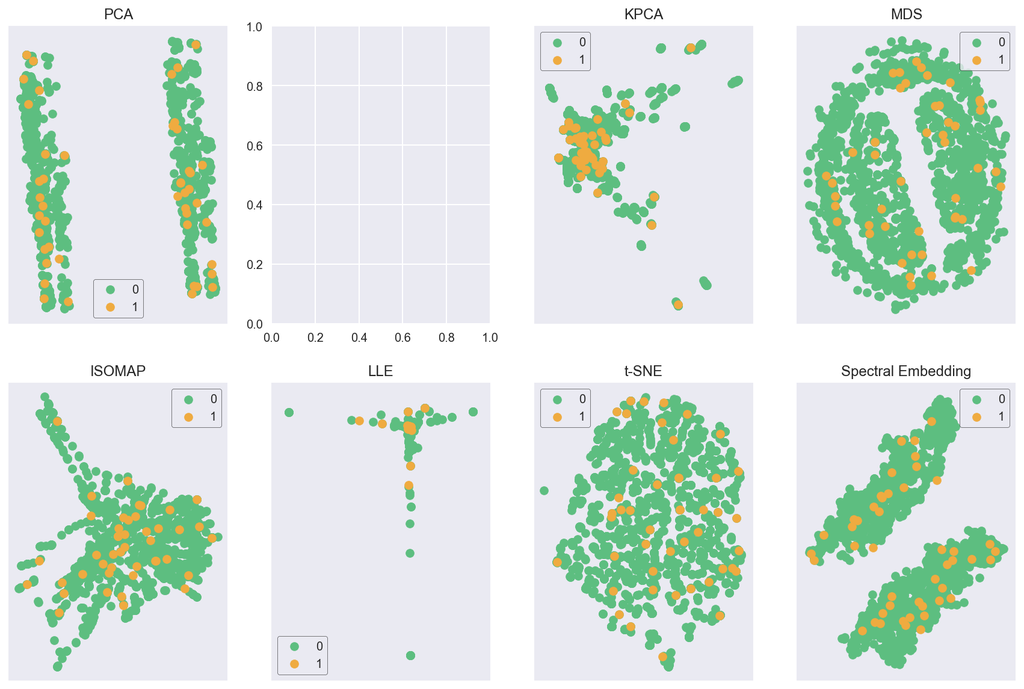

```python
fig, axes = plt.subplots(2,4,figsize=(15,10))

# 数据太多，运行太慢，我们只选取前3000行进行可视化
plot_2d(train_x.ix[0:3000],train_y.ix[0:3000])
```

可以看出，二维平面并不能看出原始数据的内嵌结构，接下来再看一下数据降维是否会影响模型的性能。

### PCA降维的主成分对原始数据方差的解释程度

在使用PCA或者LDA降维后，我们可以通过`explained_variance_ratio_`方法获得降维后的成分对原始数据方差的解释程度，这里我们以PCA为例。

```python
# 构建pca_var_explained_df数据框，便于后续用seaborn作图
components = 10
pca = decomposition.PCA(n_components=components).fit(train_x)
pca_var_explained_df = pd.DataFrame({'principal component':np.arange(1,components+1),
                                    'variance_explained':pca.explained_variance_ratio_})
pca_var_explained_df
```

|  | principal component | variance_explained |
| --- | --- | --- |
| 0 | 1 | 0.122913 |
| 1 | 2 | 0.085296 |
| 2 | 3 | 0.076348 |
| 3 | 4 | 0.072643 |
| 4 | 5 | 0.056122 |
| 5 | 6 | 0.046553 |
| 6 | 7 | 0.045512 |
| 7 | 8 | 0.041940 |
| 8 | 9 | 0.036773 |
| 9 | 10 | 0.036038 |

然后我们以各主成分为横坐标，相应的对原始数据的解释程度为纵坐标作柱状图：

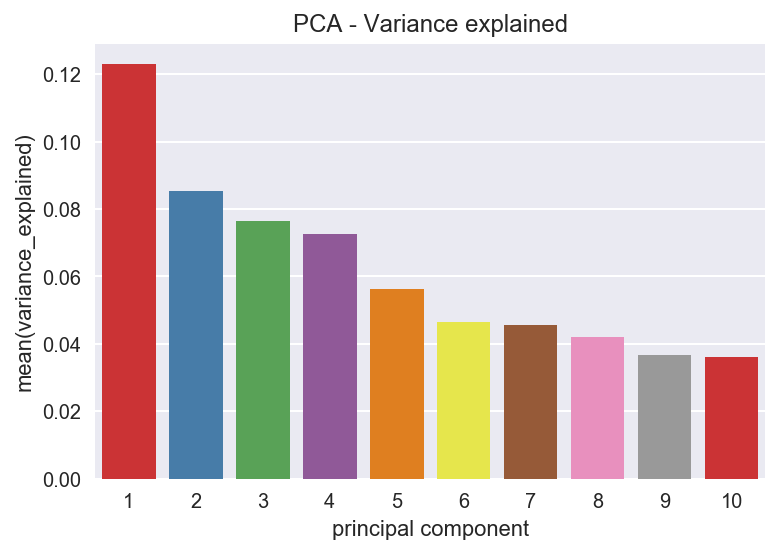

```python
ax = sns.barplot(x='principal component',
                 y='variance_explained',
                 data=pca_var_explained_df,
                 palette="Set1")
ax.set_title('PCA - Variance explained')
```

可见对于我们使用的数据集`train_x`吗，PCA降维得到的主成分对原始数据方差的解释程度比较低。

### 构建模型预测及评价函数

这里使用Extratree模型进行探讨。

```python
"""
函数model_evaluate用于计算将数据映射到不同维度的低维空间对模型性能的影响；
输入----------------------------------------------
     n_components：低维空间维度，Int
     names_specified：指定使用的降维方法，List
     train_x：不含标签列的训练集，DataFrame或者ndarray
     train_y：训练集标签，DataFrame或者ndarray
     test_x：不含标签列的测试集，DataFrame或者ndarray
     test_y：测试集标签，DataFrame或者ndarray
    ----------------------------------------------
输出
    f1_all：Extratree集成分类器在测试集上的预测F1分数，Dictionary
"""
def model_evaluate(n_components, names_specified, train_x, train_y, test_x, test_y):

    f1_all = {}

    # 创建各个降维类的实例
    pca = decomposition.PCA(n_components=n_components)
    lda = discriminant_analysis.LinearDiscriminantAnalysis(n_components=n_components)
    kpca = decomposition.KernelPCA(n_components=n_components,kernel="rbf", fit_inverse_transform=True, gamma=.8)
    mds = manifold.MDS(n_components=n_components,n_init=1,max_iter=100)
    iso = manifold.Isomap(n_components=n_components,n_neighbors=2)
    lle = manifold.LocallyLinearEmbedding(n_components=n_components,n_neighbors=3)
    tsne = manifold.TSNE(n_components=n_components,init='pca',random_state=10)
    spectral = manifold.SpectralEmbedding(n_components=n_components,random_state=10,eigen_solver='arpack')

    # 建立以降维名字为names为键，具体的降维模型algorithms为值的字典name_algorithm，便于之后指定降维方法进行数据降维
    algorithms = [pca,lda,kpca,mds,iso,lle,tsne,spectral]
    name_algorithm={}
    for name,algorithm in zip(names,algorithms):
        name_algorithm[name]=algorithm

    # 通过names_specified参数，指定使用的降维方法algorithms_specified
    algorithms_specified = []
    for name in names_specified:
        algorithms_specified.append(name_algorithm[name])

    # 通过指定的降维方法进行降维，构建Extratree集成分类器，并进行模型评估
    for i,algorithm in enumerate(algorithms_specified):
        if algorithm==lda:
            train_x_embed = algorithm.fit_transform(train_x,train_y)
            #####?????####
        else:
            # 某些降维方法不存在transform方法，对这些方法不做讨论
            if hasattr(algorithm,'transform'):
                dimen_reduct = algorithm.fit(train_x)
                train_x_embed = dimen_reduct.transform(train_x)
                test_x_embed = dimen_reduct.transform(test_x)
                clf_entropy = ExtraTreesClassifier(criterion='entropy')
                model = clf_entropy.fit(train_x_embed, train_y)
                pred = model.predict(test_x_embed)
                f1_all[names_specified[i]] = metrics.f1_score(test_y,pred,average='weighted')
    return f1_all
```

比如我们将数据映射到二维空间中，再构建模型，得到的Extratree的预测性能如下（由于对于某些需要计算距离的降维方法运行时间上消耗较大，我们只选取前训练集的5000行进行建模，读者可以尝试使用完整训练集进行建模）：

```python
model_evaluate(n_components=2, names_specified=names, train_x=train_x.ix[:5000], train_y=train_y.ix[:5000], test_x=test_x, test_y=test_y)
```

```
{'ISOMAP': 0.83671118951887891,
 'KPCA': 0.83682160906456449,
 'LLE': 0.83356520620378527,
 'PCA': 0.83406945679713396}
```

### 降维后的特征个数`n_components`对模型性能的影响

可以看出，由于我们只对包含`transform`方法的数据降维类进行模型构建，因此只得到了ISOMAP、KPCA、LLE、PCA四种降维方法处理后的模型F1分数。以PCA为例，接下来我们考察使用PCA方法将数据映射在不同低维空间然后构建模型得到的模型预测性能上的差别，将结果存储在嵌套字典`f1`中：

```python
f1={}
names_specified=['PCA']
# 低维空间分别取{2,3,...,10}维进行建模
for n_components in range(2,11):
    f1[n_components]=model_evaluate(n_components, names_specified, train_x, train_y, test_x, test_y)
f1
```

```
{2: {'PCA': 0.84600784707138021},
 3: {'PCA': 0.84674467054192137},
 4: {'PCA': 0.8504063096731036},
 5: {'PCA': 0.84801585701512616},
 6: {'PCA': 0.84493391480733804},
 7: {'PCA': 0.84659116460711026},
 8: {'PCA': 0.84738397942893151},
 9: {'PCA': 0.84562531768201354},
 10: {'PCA': 0.84463661437292181}}
```

在得到预测结果后，为了便于作图，我们需要将结果转换为dataframe，转换的最终结果期望为以`n_components`以及不同降维方法下（以降维名称为列名）的模型F1分数值为不同列的数据框`diff_n_components`：

```python
# 构建pca_var_explained_df数据框，便于后续用seaborn作图
components = 10
diff_n_components = pd.DataFrame({'n_components':f1.keys()})
for name in names_specified:

    # 得到模型预测结果f1_score，并将其转换为数据框f1_score_df
    for name in names_specified:
        f1_score=[]
        for key in f1.keys():
            f1_score.append(f1[key][name])
        f1_score_df = pd.DataFrame({name:f1_score})

        # 将f1_score_df与diff_n_component作拼接
        diff_n_components = pd.concat([diff_n_components,f1_score_df],axis=1)
diff_n_components
```

|  | n_components | PCA |
| --- | --- | --- |
| 0 | 2 | 0.846008 |
| 1 | 3 | 0.846745 |
| 2 | 4 | 0.850406 |
| 3 | 5 | 0.848016 |
| 4 | 6 | 0.844934 |
| 5 | 7 | 0.846591 |
| 6 | 8 | 0.847384 |
| 7 | 9 | 0.845625 |
| 8 | 10 | 0.844637 |

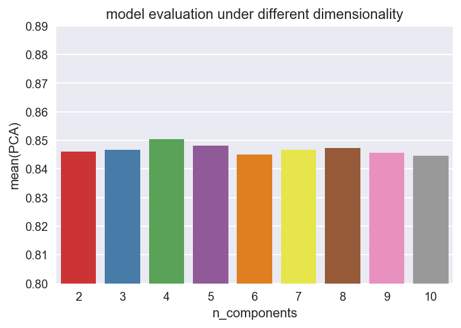

```python
for name in names_specified:
    ax = sns.barplot(x='n_components',
                     y=name,
                     data=diff_n_components,
                     palette="Set1")
    ax.set_title('model evaluation under different dimensionality')
    plt.ylim(0.80,0.89)
```

从结果可以看出`n_components`对模型性能影响不大。

### 数据降维对模型预测性能的影响

以上只是从模型的参数角度进行了分析，那么我们最关心的问题是，是否数据降维对构建的模型性能有明显的影响，与特征选择方法得出的模型性能有有何差异。我们将要使用到的数据集有：

| 数据集名 | 含义 |
| --- | --- |
| `train_x` | 包含56个特征的训练数据集 |
| `test_x` | 包含56个特征的测试数据集 |
| `new_train_x` | 包含特征选择得到的6个特征的训练数据集 |
| `new_test_x` | 包含特征选择得到的6个特征的测试数据集 |
| `train_y` | 训练集真实标签 |
| `test_y` | 测试集真实标签 |

```python
x_labels = ['Original','Feature Selection','Dimensionality Reduction (PCA)']
f1_scores = []
datasets = []

# 原始数据集(56个特征)下的模型预测性能
clf_entropy = ExtraTreesClassifier(criterion='entropy')
clf_entropy = clf_entropy.fit(train_x, train_y)
pred=clf_entropy.predict(test_x)
f1_scores.append(metrics.f1_score(test_y,pred,average='weighted'))

# 特征选择方法得到的数据集(6个特征)下的模型预测性能
clf_entropy = ExtraTreesClassifier(criterion='entropy')
clf_entropy = clf_entropy.fit(new_train_x, train_y)
pred=clf_entropy.predict(new_test_x)
f1_scores.append(metrics.f1_score(test_y,pred,average='weighted'))

# PCA数据降维方法得到(映射到6维)的模型预测性能
f1_scores.append(f1[6]['PCA'])

f1_scores
```

```
[0.86953356117552894, 0.87380213655832173, 0.84493391480733804]
```

[output not shown]

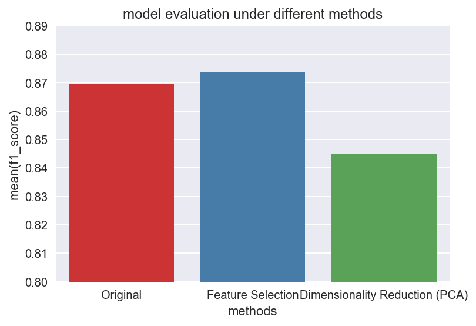

```python
tmp = zip(x_labels,f1_scores)
method_comp = pd.DataFrame(tmp,columns=["methods","f1_score"])

ax = sns.barplot(x='methods',
                 y='f1_score',
                 data=method_comp,
                 palette="Set1")
ax.set_title('model evaluation under different methods')
plt.ylim(0.80,0.89)
```

特征选择方法对于模型确实有提升效果，但是对于数据降维方法而言，效果不如特征选择方法，这与具体的数据集有关，当数据特征达到上万级别时，数据降维对于模型的解释是有利的。我们接下来再继续讨论调参的过程。